```python
import pandas as pd
from sklearn.linear_model import LinearRegression
```

```python
housing = pd.read_csv("/Users/moizzah/Desktop/housing/housing.csv")
housing_df = housing[['housing_median_age', 'total_rooms',
       'total_bedrooms', 'population', 'households', 'median_income',
       'median_house_value','ocean_proximity']].copy()
```

```python
median = housing_df['total_bedrooms'].median()
housing_df['total_bedrooms'].fillna(median, inplace = True)
```

```python
proximity_mapping = {'ocean_proximity': {'INLAND': 1, 'NEAR OCEAN': 2, 'NEAR BAY': 3, 'ISLAND': 4, '<1H OCEAN':5}}
proximity_mapping.items()
housing_df.replace(proximity_mapping, inplace = True)
```

```python
from sklearn.preprocessing import StandardScaler as ss
temp = housing_df[['housing_median_age', 'total_rooms',
       'total_bedrooms', 'population', 'households', 'median_income',
       'median_house_value']].copy()
temp = ss().fit_transform(temp)
```

```python
housing_df[['housing_median_age', 'total_rooms',
       'total_bedrooms', 'population', 'households', 'median_income',
       'median_house_value']] = temp
```

```python
housing_df.info()
```

```
<class 'pandas.core.frame.DataFrame'>
RangeIndex: 20640 entries, 0 to 20639
Data columns (total 8 columns):
housing_median_age    20640 non-null float64
total_rooms           20640 non-null float64
total_bedrooms        20640 non-null float64
population            20640 non-null float64
households            20640 non-null float64
median_income         20640 non-null float64
median_house_value    20640 non-null float64
ocean_proximity       20640 non-null int64
dtypes: float64(7), int64(1)
memory usage: 1.3 MB
```

```python
housing_pred = housing_df.iloc[:, [0,1,2,3,4,5,7]]
housing_pred.head()
```

|  | housing_median_age | total_rooms | total_bedrooms | population | households | median_income | ocean_proximity |
| --- | --- | --- | --- | --- | --- | --- | --- |
| 0 | 0.982143 | -0.804819 | -0.972476 | -0.974429 | -0.977033 | 2.344766 | 3 |
| 1 | -0.607019 | 2.045890 | 1.357143 | 0.861439 | 1.669961 | 2.332238 | 3 |
| 2 | 1.856182 | -0.535746 | -0.827024 | -0.820777 | -0.843637 | 1.782699 | 3 |
| 3 | 1.856182 | -0.624215 | -0.719723 | -0.766028 | -0.733781 | 0.932968 | 3 |
| 4 | 1.856182 | -0.462404 | -0.612423 | -0.759847 | -0.629157 | -0.012881 | 3 |

```python
housing_targ = housing_df.iloc[:, [6]]
housing_targ.head()
```

|  | median_house_value |
| --- | --- |
| 0 | 2.129631 |
| 1 | 1.314156 |
| 2 | 1.258693 |
| 3 | 1.165100 |
| 4 | 1.172900 |

Split the data set into training and test examples

```python
from sklearn.model_selection import train_test_split
```

```python
x_housing_train, x_housing_test, y_housing_train, y_housing_test = train_test_split(housing_pred, housing_targ, test_size = 0.3, random_state = 123)
```

## Linear Regression

```python
linReg = LinearRegression().fit(x_housing_train,y_housing_train)
```

```python
linReg.coef_
```

```
array([[ 0.16858844, -0.16516143,  0.21052231, -0.44098006,  0.43693961,
         0.69922856,  0.11090314]])
```

```python
linReg.intercept_
```

```
array([-0.34288165])
```

```python
housing_pred = linReg.predict(x_housing_test)
```

Measuring the performance of the model

```python
from sklearn.metrics import mean_squared_error, mean_absolute_error
```

```python
linReg_MSE = mean_squared_error(y_housing_test, housing_pred)
linReg_MSE
```

```
0.3982559199256769
```

```python
linReg_MAE = mean_absolute_error(y_housing_test, housing_pred)
linReg_MAE
```

```
0.46026484588259703
```

```python
import matplotlib as mpl
%matplotlib inline
```

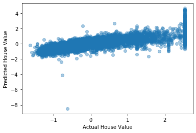

```python
mpl.pyplot.scatter(x = y_housing_test, y = housing_pred, alpha = 0.4)
mpl.pyplot.title = ('Linear Regression - Actual vs Predicted')
mpl.pyplot.xlabel('Actual House Value')
mpl.pyplot.ylabel('Predicted House Value')
mpl.pyplot.show()
```

## Logistic regression - Binary classification

```python
titanic = pd.read_csv('/Users/moizzah/Desktop/titanic/train.csv')
```

```python
titanic.head()
```

|  | PassengerId | Survived | Pclass | Name | Sex | Age | SibSp | Parch | Ticket | Fare | Cabin | Embarked |
| --- | --- | --- | --- | --- | --- | --- | --- | --- | --- | --- | --- | --- |
| 0 | 1 | 0 | 3 | Braund, Mr. Owen Harris | male | 22.0 | 1 | 0 | A/5 21171 | 7.2500 | NaN | S |
| 1 | 2 | 1 | 1 | Cumings, Mrs. John Bradley (Florence Briggs Th... | female | 38.0 | 1 | 0 | PC 17599 | 71.2833 | C85 | C |
| 2 | 3 | 1 | 3 | Heikkinen, Miss. Laina | female | 26.0 | 0 | 0 | STON/O2. 3101282 | 7.9250 | NaN | S |
| 3 | 4 | 1 | 1 | Futrelle, Mrs. Jacques Heath (Lily May Peel) | female | 35.0 | 1 | 0 | 113803 | 53.1000 | C123 | S |
| 4 | 5 | 0 | 3 | Allen, Mr. William Henry | male | 35.0 | 0 | 0 | 373450 | 8.0500 | NaN | S |

```python
titanic.info()
```

```
<class 'pandas.core.frame.DataFrame'>
RangeIndex: 891 entries, 0 to 890
Data columns (total 12 columns):
PassengerId    891 non-null int64
Survived       891 non-null int64
Pclass         891 non-null int64
Name           891 non-null object
Sex            891 non-null object
Age            714 non-null float64
SibSp          891 non-null int64
Parch          891 non-null int64
Ticket         891 non-null object
Fare           891 non-null float64
Cabin          204 non-null object
Embarked       889 non-null object
dtypes: float64(2), int64(5), object(5)
memory usage: 83.7+ KB
```

The variable cabin has quite a high ratio of missing values  
whereas Variable Emabrked has only 2 missing values  
Age has around 20% values missing

```python
#drop rows where Embarked has missing values
titanic.dropna(subset = ['Embarked'], inplace = True)
```

see distribution of survival

```python
import seaborn as sb
```

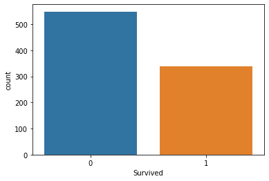

```python
sb.countplot(x = 'Survived', data = titanic)
```

See who survived and did not w.r.t to their cabin class

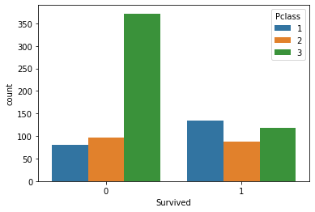

```python
sb.countplot(x='Survived', data = titanic, hue = 'Pclass')
```

```python
titanic.info()
```

```
<class 'pandas.core.frame.DataFrame'>
Int64Index: 889 entries, 0 to 890
Data columns (total 12 columns):
PassengerId    889 non-null int64
Survived       889 non-null int64
Pclass         889 non-null int64
Name           889 non-null object
Sex            889 non-null object
Age            712 non-null float64
SibSp          889 non-null int64
Parch          889 non-null int64
Ticket         889 non-null object
Fare           889 non-null float64
Cabin          202 non-null object
Embarked       889 non-null object
dtypes: float64(2), int64(5), object(5)
memory usage: 90.3+ KB
```

```python
#drop the column Cabin
titanic = titanic.loc[:, titanic.columns != 'Cabin']
titanic.info()
```

```
<class 'pandas.core.frame.DataFrame'>
Int64Index: 889 entries, 0 to 890
Data columns (total 11 columns):
PassengerId    889 non-null int64
Survived       889 non-null int64
Pclass         889 non-null int64
Name           889 non-null object
Sex            889 non-null object
Age            712 non-null float64
SibSp          889 non-null int64
Parch          889 non-null int64
Ticket         889 non-null object
Fare           889 non-null float64
Embarked       889 non-null object
dtypes: float64(2), int64(5), object(4)
memory usage: 83.3+ KB
```

Impute the age column with mean age

```python
mean_age = titanic['Age'].mean()
titanic['Age'].fillna(mean_age, inplace = True)
titanic.info()
```

```
<class 'pandas.core.frame.DataFrame'>
Int64Index: 889 entries, 0 to 890
Data columns (total 11 columns):
PassengerId    889 non-null int64
Survived       889 non-null int64
Pclass         889 non-null int64
Name           889 non-null object
Sex            889 non-null object
Age            889 non-null float64
SibSp          889 non-null int64
Parch          889 non-null int64
Ticket         889 non-null object
Fare           889 non-null float64
Embarked       889 non-null object
dtypes: float64(2), int64(5), object(4)
memory usage: 83.3+ KB
```

select the predictor + target variables  
you may not need some of the features as predictor

```python
titanic_df = titanic[['Survived', 'Pclass', 'Sex', 'Age', 'SibSp', 'Parch', 'Embarked']]
titanic_df.info()
```

```
<class 'pandas.core.frame.DataFrame'>
Int64Index: 889 entries, 0 to 890
Data columns (total 7 columns):
Survived    889 non-null int64
Pclass      889 non-null int64
Sex         889 non-null object
Age         889 non-null float64
SibSp       889 non-null int64
Parch       889 non-null int64
Embarked    889 non-null object
dtypes: float64(1), int64(4), object(2)
memory usage: 55.6+ KB
```

map the character features to numeric

```python
sex_mapping = {'Sex': {'female': 1, 'male': 2}}
sex_mapping.items()
```

```
dict_items([('Sex', {'female': 1, 'male': 2})])
```

```python
titanic_df.replace(sex_mapping, inplace = True)
titanic_df.head()
```

|  | Survived | Pclass | Sex | Age | SibSp | Parch | Embarked |
| --- | --- | --- | --- | --- | --- | --- | --- |
| 0 | 0 | 3 | 2 | 22.0 | 1 | 0 | S |
| 1 | 1 | 1 | 1 | 38.0 | 1 | 0 | C |
| 2 | 1 | 3 | 1 | 26.0 | 0 | 0 | S |
| 3 | 1 | 1 | 1 | 35.0 | 1 | 0 | S |
| 4 | 0 | 3 | 2 | 35.0 | 0 | 0 | S |

```python
titanic_df['Embarked'].unique()
```

```
array(['S', 'C', 'Q'], dtype=object)
```

```python
embarked_mapping = {'Embarked': {'C': 1, 'Q': 2,'S':3 }}
embarked_mapping.items()
```

```
dict_items([('Embarked', {'C': 1, 'Q': 2, 'S': 3})])
```

```python
titanic_df.replace(embarked_mapping, inplace = True)
titanic_df.head()
```

|  | Survived | Pclass | Sex | Age | SibSp | Parch | Embarked |
| --- | --- | --- | --- | --- | --- | --- | --- |
| 0 | 0 | 3 | 2 | 22.0 | 1 | 0 | 3 |
| 1 | 1 | 1 | 1 | 38.0 | 1 | 0 | 1 |
| 2 | 1 | 3 | 1 | 26.0 | 0 | 0 | 3 |
| 3 | 1 | 1 | 1 | 35.0 | 1 | 0 | 3 |
| 4 | 0 | 3 | 2 | 35.0 | 0 | 0 | 3 |

create predictor dataframe and target array  
split data into train and test

```python
titanic_df.info()
```

```
<class 'pandas.core.frame.DataFrame'>
Int64Index: 889 entries, 0 to 890
Data columns (total 7 columns):
Survived    889 non-null int64
Pclass      889 non-null int64
Sex         889 non-null int64
Age         889 non-null float64
SibSp       889 non-null int64
Parch       889 non-null int64
Embarked    889 non-null int64
dtypes: float64(1), int64(6)
memory usage: 55.6 KB
```

```python
x_titanic = titanic_df.iloc[:,1:7]

x_titanic.head()
```

|  | Pclass | Sex | Age | SibSp | Parch | Embarked |
| --- | --- | --- | --- | --- | --- | --- |
| 0 | 3 | 2 | 22.0 | 1 | 0 | 3 |
| 1 | 1 | 1 | 38.0 | 1 | 0 | 1 |
| 2 | 3 | 1 | 26.0 | 0 | 0 | 3 |
| 3 | 1 | 1 | 35.0 | 1 | 0 | 3 |
| 4 | 3 | 2 | 35.0 | 0 | 0 | 3 |

```python
y_titanic = titanic_df.iloc[:,0]
y_titanic.head()
```

```
0    0
1    1
2    1
3    1
4    0
Name: Survived, dtype: int64
```

```python
x_titanic_train, x_titanic_test, y_titanic_train, y_titanic_test = train_test_split(x_titanic, y_titanic, test_size = 0.3, random_state = 101)
```

```python
from sklearn.linear_model import LogisticRegression
```

```python
logit = LogisticRegression(verbose = 1).fit(x_titanic_train, y_titanic_train)
```

```
[LibLinear]
```

```python
logit_pred = logit.predict(x_titanic_test)
```

measure the performance of the classification model  
confusion matrix

```
TP | FN
_______

FP | TN
```

Accuracy = (TP+TN)/(TP+FP+FP+FN)

Precision is the ratio of correctly predicted positive observations to the total predicted positive observations

```
precision = TP/(TP+FP)
```

Recall is the ratio of correctly predicted positive observations to all the actual positive observations

```
recall = TP/(TP+FN)
```

Score is the weighted average of Precision and Recall. Therefore, this score takes both false positives and false negatives into account.  
accuracy can be largely contributed by a large number of True Negatives which in most business circumstances, we do not focus on much whereas False Negative and False Positive usually has business costs

```
f1 = 2((precision * recall)/(precision + recall))
```

```python
from sklearn.metrics import confusion_matrix, accuracy_score, precision_score, recall_score, f1_score
```

```python
confusion_matrix(y_titanic_test, logit_pred)
```

```
array([[150,  13],
       [ 37,  67]])
```

```python
accuracy_score(y_titanic_test, logit_pred)
```

```
0.8127340823970037
```

```python
precision_score(y_titanic_test, logit_pred)
```

```
0.8375
```

```python
recall_score(y_titanic_test, logit_pred)
```

```
0.6442307692307693
```

```python
f1_score(y_titanic_test, logit_pred)
```

```
0.7282608695652174
```

## Decision Trees

```python
from sklearn.tree import DecisionTreeClassifier
```

```python
tree_overfit = DecisionTreeClassifier(criterion = 'entropy', random_state = 123)
```

```python
tree_overfit.fit(x_titanic_train, y_titanic_train)
```

```
DecisionTreeClassifier(class_weight=None, criterion='entropy', max_depth=None,
                       max_features=None, max_leaf_nodes=None,
                       min_impurity_decrease=0.0, min_impurity_split=None,
                       min_samples_leaf=1, min_samples_split=2,
                       min_weight_fraction_leaf=0.0, presort=False,
                       random_state=123, splitter='best')
```

```python
tree_overfit.score(x_titanic_train, y_titanic_train)
```

```
0.9517684887459807
```

```python
tree_overfit.score(x_titanic_test, y_titanic_test)
```

```
0.7940074906367042
```

as expected it has overfit on training set

the freedom of Decison tree needs to be restricted to overcome overfitting

let's use the hyperpaprameters of the model to do that.

max_depth - restricts the depth of the tree (only these many consecutive questions can be asked to assign class)

```python
tree_restricted = DecisionTreeClassifier(criterion = 'entropy', random_state = 123, max_depth = 4)
```

```python
tree_restricted.fit(x_titanic_train, y_titanic_train)
```

```
DecisionTreeClassifier(class_weight=None, criterion='entropy', max_depth=4,
                       max_features=None, max_leaf_nodes=None,
                       min_impurity_decrease=0.0, min_impurity_split=None,
                       min_samples_leaf=1, min_samples_split=2,
                       min_weight_fraction_leaf=0.0, presort=False,
                       random_state=123, splitter='best')
```

```python
tree_restricted.score(x_titanic_train, y_titanic_train)
```

```
0.8344051446945338
```

```python
tree_restricted.score(x_titanic_test, y_titanic_test)
```

```
0.8426966292134831
```

let's see feature importance

```python
print(tree_restricted.feature_importances_)
```

```
[0.21135129 0.52649497 0.16778247 0.06395597 0.00792949 0.02248581]
```

```python
print(tree_overfit.feature_importances_)
```

```
[0.12077567 0.26312219 0.42043487 0.10437981 0.05596368 0.03532378]
```